# Reproducible Research

### Imputing missing values

1. Calculate and report the total number of missing values in the dataset (i.e. the total number of rows with NAs)

```r
totalNA <- sqldf('SELECT ad.* FROM "activityData" as ad
    WHERE ad.steps IS NULL ORDER BY ad.date, ad.interval ')
```

Total Number of missing values: 2304

2. Devise a strategy for filling in all of the missing values in the dataset. The strategy does not need to be sophisticated. For example, you could use the mean/median for that day, or the mean for that 5-minute interval, etc.

```r
activityDataNA <- na.omit(activityData)
intervals <- ddply(activityDataNA,~interval, summarise, mean=mean(steps))
results <- sqldf('SELECT ad.*, ada.mean  FROM "intervals" as ada
    JOIN "activityData" as ad
    ON ad.interval = ada.interval
    ORDER BY ad.date, ad.interval ')
```

3. Create a new dataset that is equal to the original dataset but with the missing data filled in.

```r
results$steps[is.na(results$steps)] <- results$mean[is.na(results$steps)]
```

Prepare data to plot

```r
ResultsTotalSteps <- as.integer( sqldf('
    SELECT sum(steps)
    FROM results') )

ResultsTotalStepsDaily <- sqldf('
    SELECT date, sum(steps) as "ResultsTotalStepsDaily"
    FROM results GROUP BY date
    ORDER BY date')

Resultsdailysteps <- sqldf('
    SELECT date, ResultsTotalStepsDaily as "steps"
    FROM "ResultsTotalStepsDaily"
    ORDER BY date')
```

Histogram of the total number of steps taken each day.

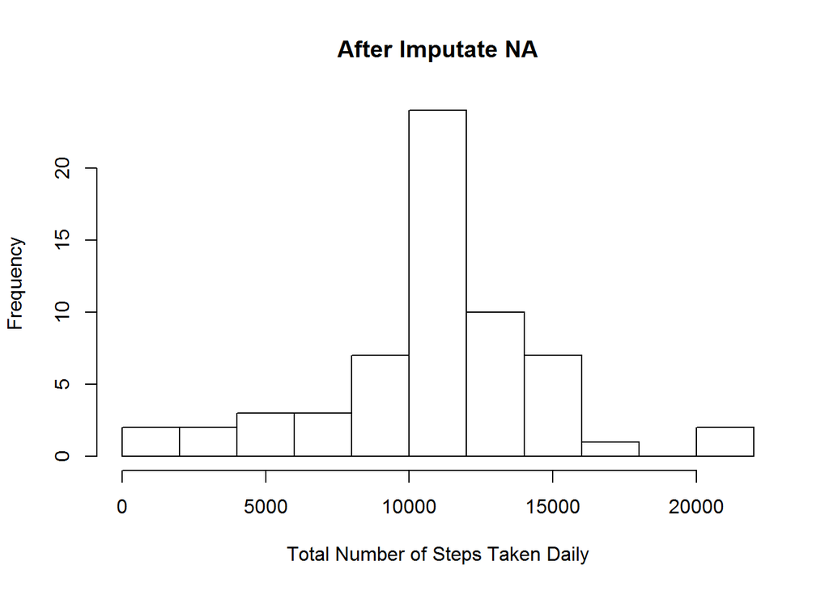

```r
hist(Resultsdailysteps$steps,
     main="After Imputate NA",
     breaks=10,
     xlab="Total Number of Steps Taken Daily")
```

### Are there differences in activity patterns between weekdays and weekends?

Adding a column called (Week).

```r
results$week <- as.factor(ifelse(weekdays(results$date) %in%
                                         c("sabado","domingo"),"weekend", "weekday"))


ResultsWeek <- sqldf('
    SELECT interval, avg(steps) as "AverageSteps", week
    FROM results
    GROUP BY week, interval
    ORDER BY interval ')
```

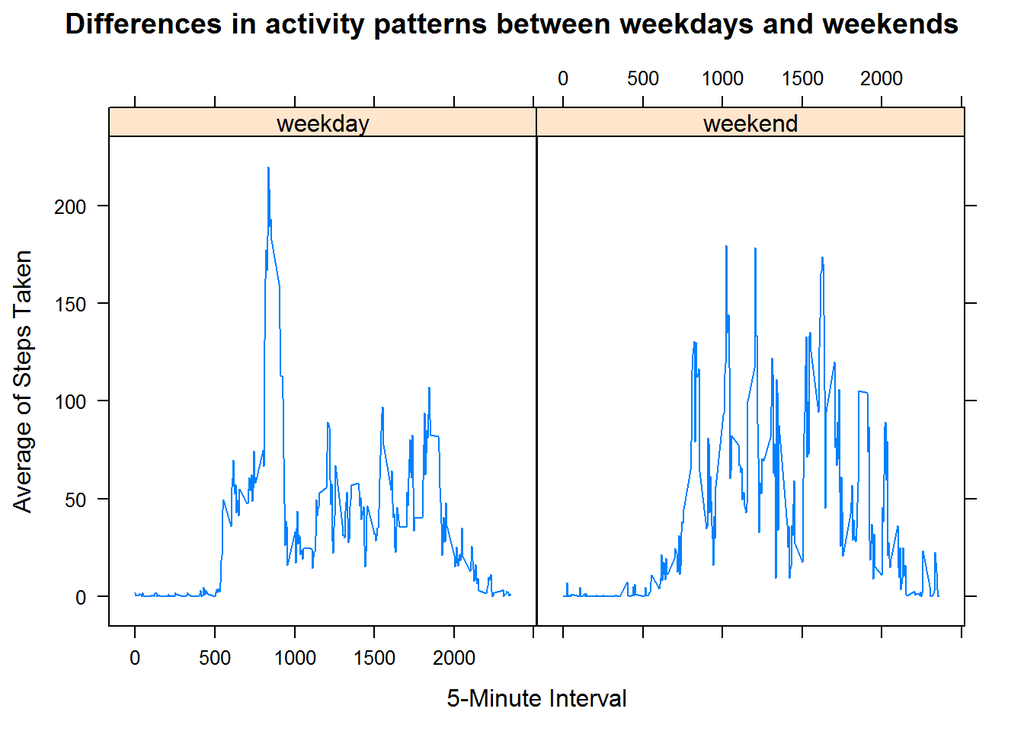

```r
p <- xyplot(AverageSteps ~ interval | factor(week), data=ResultsWeek,
            type = 'l',
            main="Differences in activity patterns between weekdays and weekends",
            xlab="5-Minute Interval",
            ylab="Average of Steps Taken")
print (p)
```

*Yes. There are more activities at weekend*